# lab3wei

2024-10-20

```r
library(nycflights13)
library(tidyverse)
```

### 5.5.2

1. Currently dep_time and sched_dep_time are convenient to look at, but hard to compute with because they’re not really continuous numbers. Convert them to a more convenient representation of number of minutes since midnight. Then, compare the difference between these new variables to each flight’s dep_delay value. Does anything surprise you? Can you explain what accounts for the “anomaly”? How many cases do you observe?

```r
flights <-mutate(flights,
       dep_time1 = (dep_time %/% 100) * 60 + (dep_time %% 100),
       sched_dep_time1 = (sched_dep_time %/% 100) * 60 + (sched_dep_time %% 100))
```

```r
# compare new variables with dep_delay
select(flights, dep_time1, sched_dep_time1, dep_delay)
```

```
## # A tibble: 336,776 × 3
##    dep_time1 sched_dep_time1 dep_delay
##        <dbl>           <dbl>     <dbl>
##  1       317             315         2
##  2       333             329         4
##  3       342             340         2
##  4       344             345        -1
##  5       354             360        -6
##  6       354             358        -4
##  7       355             360        -5
##  8       357             360        -3
##  9       357             360        -3
## 10       358             360        -2
## # ℹ 336,766 more rows
```

```r
flights <- mutate(flights, dep_diff = dep_time1-sched_dep_time1)
```

```r
comparison <- flights %>%
  mutate(anomaly = dep_diff != dep_delay)
comparison %>% filter(anomaly == TRUE) %>% count()
```

```
## # A tibble: 1 × 1
##       n
##   <int>
## 1  1207
```

```r
# Display the first five observations with relevant columns
flights %>%
  select(carrier, flight, dep_time1, sched_dep_time1, dep_diff, dep_delay) %>%
  head(5)
```

```
## # A tibble: 5 × 6
##   carrier flight dep_time1 sched_dep_time1 dep_diff dep_delay
##   <chr>    <int>     <dbl>           <dbl>    <dbl>     <dbl>
## 1 UA        1545       317             315        2         2
## 2 UA        1714       333             329        4         4
## 3 AA        1141       342             340        2         2
## 4 B6         725       344             345       -1        -1
## 5 DL         461       354             360       -6        -6
```

The difference in dep_time1 and sched_dep_time is given by dep_delay. Overall, there are around 1207 cases where the difference in new variables is not equal to dep_delay.

### 5.6.7

2. Is the proportion of canceled flights per day related to the average delay for that day? Output a csv file that will allow you to make a scatter plot of the proportion of cancelled flights vs. the average delay for that day

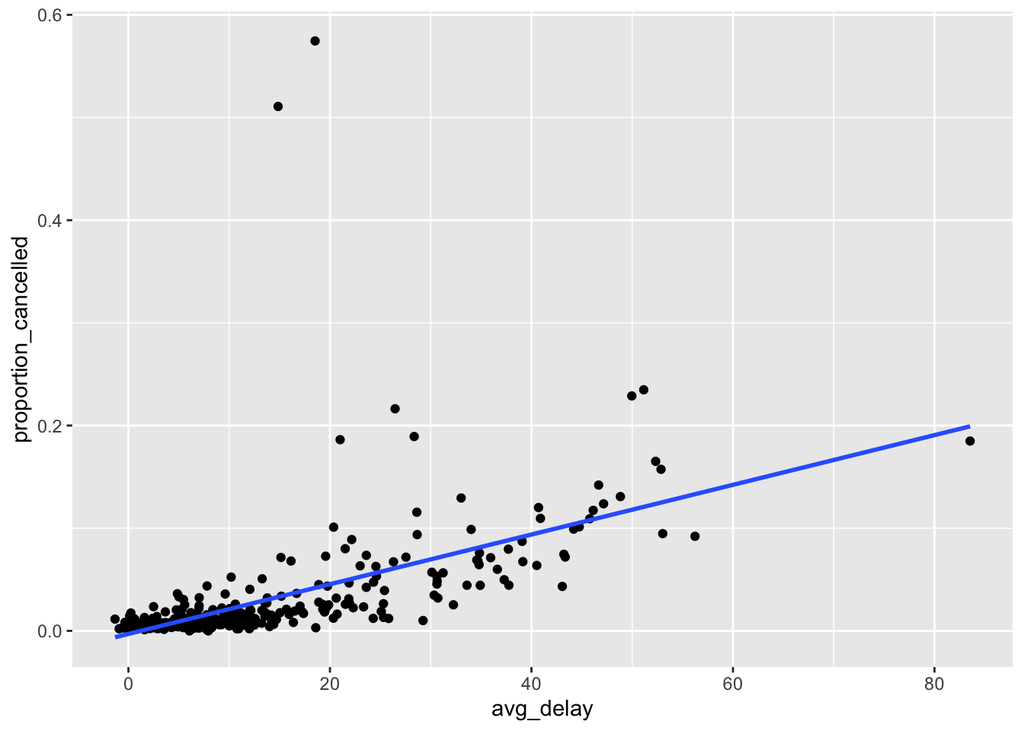

```r
flights %>%
  mutate(
    cancelled = is.na(dep_delay) | is.na(arr_delay)) %>%
    group_by(month, day) %>%
  summarise(
    total_flights = n(),  # Total number of flights per day
    cancelled_flights = sum(cancelled),  # Total number of cancelled flights per day
    proportion_cancelled = mean(cancelled),  # Proportion of cancelled flights per day
    avg_delay = mean(dep_delay, na.rm = TRUE)  # Average departure delay (ignore NA values)
  ) %>%
  ggplot(mapping = aes(x = avg_delay, y = proportion_cancelled)) +
  geom_point() +
  geom_smooth(method = 'lm', se = FALSE)
```

5. Which carrier, on average, has the shortest departure delays? In your response, provide the name of the airline, not simply two-letter carrier code. Contextualize this delay with respect to delays of other airlines.

```r
# Calculate the average departure delay per carrier
average_delay <- flights %>%
  filter(!is.na(dep_delay)) %>%  # Filter out missing departure delays
  group_by(carrier) %>%  # Group by carrier
  summarise(avg_dep_delay = mean(dep_delay)) %>%  # Calculate average delay
  arrange(avg_dep_delay)  # Sort by the shortest delay

# Join with airline names for better clarity
average_delay %>%
  left_join(airlines, by = "carrier")  # airlines dataset contains full carrier names
```

```
## # A tibble: 16 × 3
##    carrier avg_dep_delay name
##    <chr>           <dbl> <chr>
##  1 US               3.78 US Airways Inc.
##  2 HA               4.90 Hawaiian Airlines Inc.
##  3 AS               5.80 Alaska Airlines Inc.
##  4 AA               8.59 American Airlines Inc.
##  5 DL               9.26 Delta Air Lines Inc.
##  6 MQ              10.6  Envoy Air
##  7 UA              12.1  United Air Lines Inc.
##  8 OO              12.6  SkyWest Airlines Inc.
##  9 VX              12.9  Virgin America
## 10 B6              13.0  JetBlue Airways
## 11 9E              16.7  Endeavor Air Inc.
## 12 WN              17.7  Southwest Airlines Co.
## 13 FL              18.7  AirTran Airways Corporation
## 14 YV              19.0  Mesa Airlines Inc.
## 15 EV              20.0  ExpressJet Airlines Inc.
## 16 F9              20.2  Frontier Airlines Inc.
```

According to the tibble, we can see that US Airways has the shortest average departure delay compared to other airlines. For example, Frontier Airlines have the longest average departure delay.

### What is a suspicious multiple?

A suspicious multiple refers to values in a dataset that frequently appear as exact multiples (e.g., 5, 10, 15). These values suggest data rounding or estimation rather than precise measurement, which can distort analysis.

For example, in a dataset of flight delays, if many delays are reported as exactly 5, 10, or 15 minutes, it’s likely that these are estimates rather than exact times. Such clustering can misrepresent the true distribution of delays.

Another example could be a survey dataset records many respondents reporting their income as exactly 50,000, 100,000, or 150,000, these values could be suspicious. People often estimate or round their income to the nearest multiple of 10,000 or 50,000 when answering surveys.

Exceptions occur when multiples reflect real-world patterns, like bus schedules or work shifts aligning with specific time intervals. However, in most cases requiring precise measurements, such multiples signal potential data quality issues.

We should watch for suspicious multiples because they may introduce bias, reduce data accuracy, and distort statistical analyses. Identifying and addressing them ensures more reliable results.